# BSTA 504: Topics in R Programming

Pre-course Installation Instructions

Updated: 2023-01-08

# Pre-course installation for your computer

- R and Rstudio are two separate programs. You must install R first. Then install Rstudio desktop.
- For help, try [watching this video](https://www.youtube.com/watch?v=kOQDdJZ7Hl4&feature=youtu.be)
- Even if you have R installed already, we highly recommend installing the latest version if it has been a while since you installed it. Just follow the instructions as below to update everything.

## If you prefer to use PSU’s VLAB

You can run R and Rstudio through PSU’s virtual computing environment if you have PSU credentials (i.e. SPH students).

- Go to [vlab.pdx.edu](http://vlab.pdx.edu/)
- Sign in with your PSU (pdx.edu) credentials.
- Open/launch “Computer Lab”
- Sign in with your PSU (pdx.edu) credentials, again.
- Open Rstudio
- Read more about VLAB [here](https://www.pdx.edu/technology/vlab)

## Install R and Rstudio on your computer

### 1. Install **R** (also do this if you need to update R to version > 4.0, > 4.2 preferred)

- Windows: Download from https://cran.rstudio.com/bin/windows/base/ from the link “Download R-4.2.2 for Windows”
- Mac OS X: Download the latest .pkg file that works with your type of Mac (R-4.2.2.pkg or R-4.2.2-arm64.pkg, only one will work for you) from https://cran.rstudio.com/bin/macosx/
  - If you have a Mac, it’s also useful to download XQuartz https://www.xquartz.org/ and Xcode (mac app store)

### 2. Install **RStudio Desktop** from Posit website (also do this if you wish to update Rstudio)

- Go to https://posit.co/download/rstudio-desktop/
- Click the blue box after Step 2 which contains the download file corresponding to your operating system, i.e.

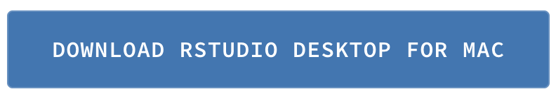

- Open the downloaded file and run the installation software.

## 3. Open Rstudio Desktop

Do not open the regular R software, it is just working in the background when you use Rstudio.

## 4. Download class materials from dropbox

Once you have installed R and Rstudio, [download the part1 class materials folder](http://bit.ly/bsta504_dropbox_2023). Open Rstudio by double clicking on `part1.rproj` file. Open the file `00-install-packages.R` by clicking on that file name in the “Files” pane. When the file opens, click “Source” at the top of the code to run the entire script.

[Here’s a quick video](https://www.youtube.com/watch?v=GU22sKHn9uc) showing you how to do all of that if you have trouble (PC users watch to 5:27 minute mark; note dropbox download may look different using other browsers).

# Prepare for the course

## *Highly recommended*

- Get acquainted with Rstudio (and R) prior to the first class. You will feel more comfortable following along with coding if you have opened the software and explored the interface on your own first.

## *Recommended*

- Try out the [interactive lessons/primers](https://posit.cloud/learn/primers) (start with The Basics) from Posit/Rstudio.

## Still want more preparation?

- View OHSU OCTRI BERD workshops that have been recorded, including “Getting Started with R and Rstudio” and “Data Wrangling with the Tidyverse”
  - Slides at github.com/jminnier/berd_r_courses
  - [Recordings are on echo](https://echo360.org/section/5bb1b2d6-aa4b-4703-a890-376180d177f5/public)
- Long list of other resources [here](https://github.com/jminnier/awesome-rstats/blob/master/learn-r.md)
- [Rstudio IDE cheatsheet](https://resources.rstudio.com/rstudio-cheatsheets/rstudio-ide-cheat-sheet)
- [Modern Dive textbook chapter getting started](https://moderndive.com/1-getting-started.html)
- [R bootcamp - interactive tutorial](https://r-bootcamp.netlify.com/) Ted Laderas & Jessica Minnier
- [Introduction to module and RStudio by Emma Rand](http://www-users.york.ac.uk/~er13/17C%20-%202018/pracs/01IntroductionToModuleAndRStudio.html)
- [Basic Basics opinionated tour of Rstudio](https://rladiessydney.org/courses/ryouwithme/01-basicbasics-0/)

# Instructor Info

[Jessica Minnier, PhD](http://jessicaminnier.com/) Oregon Health & Science University

Slides and code for BERD workshop materials: jminnier/berd_r_courses